# Homework 1

```python
import pandas as pd
import numpy as np
import seaborn as sns
import matplotlib.pyplot as plt
import warnings
warnings.filterwarnings('ignore')
sns.set(rc={'figure.figsize':(8,6)})
```

```python
def f(x):
    return (((x**3) * (np.cos(x)) * (np.sin(x))) + (3 * x**2 * (np.sin(x))) - (3 * x))
```

## Part ) 1 - Bisection method

### Task ) 1 - Drawing the Graph

- Draw the graph of the function between values a = −10 and b = 10

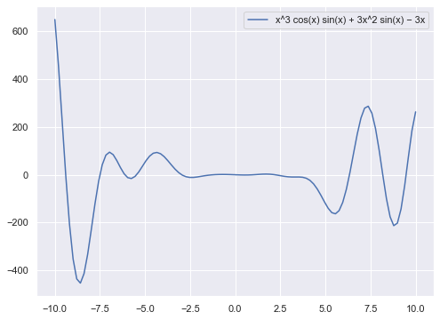

```python
X = np.linspace(-10,10,100) #generating x values between (-10,10)
plt.plot(X,f(X), label = "x^3 cos(x) sin(x) + 3x^2 sin(x) − 3x" )
plt.legend()
plt.plot();
```

```python
# Loop to find local minimum
a = np.inf
x = 0
for i in X:
    if(f(i) <= a):
        a = f(i)
        x = i
print(f"Local Minimum of the function in the given set: {a}, index : {x}")
```

```
Local Minimum of the function in the given set: -453.41175377874185, index : -8.585858585858587
```

### Task ) 2 and 3 - Deciding the parameters and drawing the point that converges

```python
# Bisection algortihm including the dataftame to keep results

def bisection(a,b,eps,f):
    interval1,interval2 = 0,0
    results = []
    iteration = 0
    x = 0
    while((b-a)>=eps):
        interval1 = a-b
        x = (a+b)/2
        if(f(x+eps)<=f(x)):
            a = x
        else:
            b = x
        interval2 = a-b
        ratio = np.abs(interval2)/np.abs(interval1)
        log_ratio = -np.log(np.abs(interval2)) + np.log(np.abs(interval1))
        results.append([a,b,x,f(x),ratio,log_ratio])
        iteration +=1
    df = pd.DataFrame(results, columns = ["a", "b", "x", "f(x)", "|x^(k+1)−x^k| / |x^k−x^(k-1)|" , "-log|x^(k+1)−x^k| + log |x^k−x^(k-1)|"])
    df.index.name = 'Iteration'
    return df,x,iteration
```

#### First Parameter Set

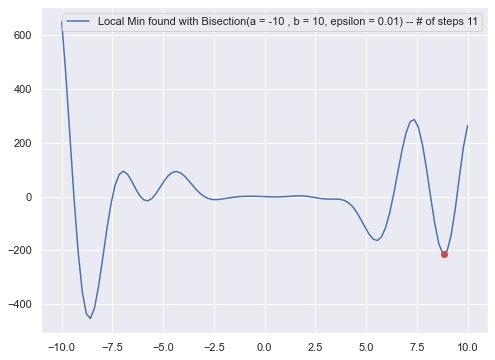

```python
# Initial Parameters was chosen as follows:

a = -10
b = 10
eps = 0.01
bisec1,bi_1_x,iteration = bisection(a,b,eps,f)

plt.plot(X,f(X), label = f"Local Min found with Bisection(a = -10 , b = 10, epsilon = 0.01) -- # of steps {iteration}" )
plt.plot(bi_1_x, f(bi_1_x), 'ro')
plt.legend()
plt.plot();
```

```python
bisec1
```

| Iteration | a | b | x | f(x) | \|x^(k+1)−x^k\| / \|x^k−x^(k-1)\| | -log\|x^(k+1)−x^k\| + log \|x^k−x^(k-1)\| |
| --- | --- | --- | --- | --- | --- | --- |
| 0 | 0.000000 | 10.000000 | 0.000000 | 0.000000 | 0.5 | 0.693147 |
| 1 | 5.000000 | 10.000000 | 5.000000 | -120.920640 | 0.5 | 0.693147 |
| 2 | 7.500000 | 10.000000 | 7.500000 | 272.957587 | 0.5 | 0.693147 |
| 3 | 8.750000 | 10.000000 | 8.750000 | -209.555318 | 0.5 | 0.693147 |
| 4 | 8.750000 | 9.375000 | 9.375000 | -55.953427 | 0.5 | 0.693147 |
| 5 | 8.750000 | 9.062500 | 9.062500 | -186.526634 | 0.5 | 0.693147 |
| 6 | 8.750000 | 8.906250 | 8.906250 | -212.880585 | 0.5 | 0.693147 |
| 7 | 8.828125 | 8.906250 | 8.828125 | -214.905766 | 0.5 | 0.693147 |
| 8 | 8.828125 | 8.867188 | 8.867188 | -214.826393 | 0.5 | 0.693147 |
| 9 | 8.828125 | 8.847656 | 8.847656 | -215.098491 | 0.5 | 0.693147 |
| 10 | 8.837891 | 8.847656 | 8.837891 | -215.060074 | 0.5 | 0.693147 |

#### Second Parameter Set

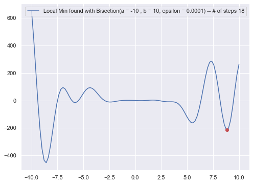

```python
# Second Parameters was chosen as follows:
# At the second step, we reduced epsilon value to find the local minimum in the given set

a = -10
b = 10
eps = 0.0001
bisec2,bi_2_x,iteration = bisection(a,b,eps,f)

plt.plot(X,f(X), label = f"Local Min found with Bisection(a = -10 , b = 10, epsilon = 0.0001) -- # of steps {iteration}" )
plt.plot(bi_2_x, f(bi_2_x), 'ro')
plt.legend()
plt.plot();
```

```python
bisec2
```

| Iteration | a | b | x | f(x) | \|x^(k+1)−x^k\| / \|x^k−x^(k-1)\| | -log\|x^(k+1)−x^k\| + log \|x^k−x^(k-1)\| |
| --- | --- | --- | --- | --- | --- | --- |
| 0 | 0.000000 | 10.000000 | 0.000000 | 0.000000 | 0.5 | 0.693147 |
| 1 | 5.000000 | 10.000000 | 5.000000 | -120.920640 | 0.5 | 0.693147 |
| 2 | 7.500000 | 10.000000 | 7.500000 | 272.957587 | 0.5 | 0.693147 |
| 3 | 8.750000 | 10.000000 | 8.750000 | -209.555318 | 0.5 | 0.693147 |
| 4 | 8.750000 | 9.375000 | 9.375000 | -55.953427 | 0.5 | 0.693147 |
| 5 | 8.750000 | 9.062500 | 9.062500 | -186.526634 | 0.5 | 0.693147 |
| 6 | 8.750000 | 8.906250 | 8.906250 | -212.880585 | 0.5 | 0.693147 |
| 7 | 8.828125 | 8.906250 | 8.828125 | -214.905766 | 0.5 | 0.693147 |
| 8 | 8.828125 | 8.867188 | 8.867188 | -214.826393 | 0.5 | 0.693147 |
| 9 | 8.828125 | 8.847656 | 8.847656 | -215.098491 | 0.5 | 0.693147 |
| 10 | 8.837891 | 8.847656 | 8.837891 | -215.060074 | 0.5 | 0.693147 |
| 11 | 8.842773 | 8.847656 | 8.842773 | -215.093791 | 0.5 | 0.693147 |
| 12 | 8.845215 | 8.847656 | 8.845215 | -215.099770 | 0.5 | 0.693147 |
| 13 | 8.845215 | 8.846436 | 8.846436 | -215.100038 | 0.5 | 0.693147 |
| 14 | 8.845825 | 8.846436 | 8.845825 | -215.100131 | 0.5 | 0.693147 |
| 15 | 8.845825 | 8.846130 | 8.846130 | -215.100142 | 0.5 | 0.693147 |
| 16 | 8.845825 | 8.845978 | 8.845978 | -215.100151 | 0.5 | 0.693147 |
| 17 | 8.845901 | 8.845978 | 8.845901 | -215.100145 | 0.5 | 0.693147 |

#### Third Parameter Set

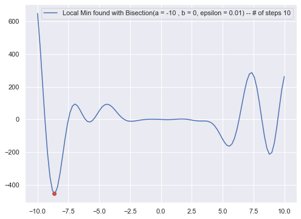

```python
# Last Parameters was chosen as follows:
# At the last step, since the right side of the center value is lower than the left side in the neighborhod of epsilon, the algortihm tend to
#go to the right side. To eliminate this problem we set a = -10 and b = 0

a = -10
b = 0
eps = 0.01
bisec3,bi_3_x,iteration = bisection(a,b,eps,f)

plt.plot(X,f(X), label = f"Local Min found with Bisection(a = -10 , b = 0, epsilon = 0.01) -- # of steps {iteration}" )
plt.plot(bi_3_x, f(bi_3_x), 'ro')
plt.legend()
plt.plot();
```

```python
bisec3
```

| Iteration | a | b | x | f(x) | \|x^(k+1)−x^k\| / \|x^k−x^(k-1)\| | -log\|x^(k+1)−x^k\| + log \|x^k−x^(k-1)\| |
| --- | --- | --- | --- | --- | --- | --- |
| 0 | -10.000000 | -5.000000 | -5.000000 | 52.918001 | 0.5 | 0.693147 |
| 1 | -10.000000 | -7.500000 | -7.500000 | 1.382595 | 0.5 | 0.693147 |
| 2 | -8.750000 | -7.500000 | -8.750000 | -444.037885 | 0.5 | 0.693147 |
| 3 | -8.750000 | -8.125000 | -8.125000 | -304.796486 | 0.5 | 0.693147 |
| 4 | -8.750000 | -8.437500 | -8.437500 | -429.110086 | 0.5 | 0.693147 |
| 5 | -8.750000 | -8.593750 | -8.593750 | -453.881297 | 0.5 | 0.693147 |
| 6 | -8.671875 | -8.593750 | -8.671875 | -453.623790 | 0.5 | 0.693147 |
| 7 | -8.671875 | -8.632812 | -8.632812 | -454.883120 | 0.5 | 0.693147 |
| 8 | -8.652344 | -8.632812 | -8.652344 | -454.540987 | 0.5 | 0.693147 |
| 9 | -8.642578 | -8.632812 | -8.642578 | -454.783353 | 0.5 | 0.693147 |

### Task ) 4 - Results

- In the epsilon neihborhood of the function, right side function values is lower than left side values. Therefore, bisection method is failing to find the local minumum at the left side of funcion because at the very first step, it eliminates the left side of the function. Unless we change the a and b values at the start of the algorithm, we are not able to find the local minimum with the bisection method. But if we adjust the a and b values according to this information, we are able to find local miminum.

## Part ) 2 - Golden-Section method

### Task ) 2 and 3 - Deciding the parameters and drawing the point that converges

```python
# Goldsection algortihm including the dataftame to keep results

def goldsection(a,b,eps,f):
    Lambda = 0.618
    interval1,interval2 = 0,0
    results = []
    iteration = 0
    x,y = 0,0
    x = b - Lambda*(b-a)
    y = a + Lambda*(b-a)
    f_x = f(x)
    f_y = f(y)
    while((b-a)>=eps):
        interval1 = a-b
        if(f_x>f_y):
            a = x
            x = y
            f_x = f_y
            y = a + Lambda*(b-a)
            f_y = f(y)
        else:
            b = y
            y = x
            x = b - Lambda * (b-a)
            f_y = f_x
            f_x = f(x)
        interval2 = a-b
        ratio = np.abs(interval2)/np.abs(interval1)
        log_ratio = -np.log(np.abs(interval2)) + np.log(np.abs(interval1))
        results.append([a,b,x,y,f(x),f(y),ratio,log_ratio])
        iteration +=1
    df = pd.DataFrame(results, columns = ["a", "b", "x","y", "f(x)","f(y)", "|x^(k+1)−x^k| / |x^k−x^(k-1)|" , "-log|x^(k+1)−x^k| + log |x^k−x^(k-1)|"])
    df.index.name = 'Iteration'
    return df,x,iteration
```

#### First Parameter Set

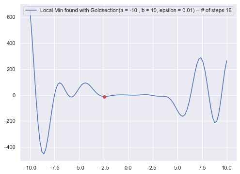

```python
# Initial Parameters was chosen as follows:

a = -10
b = 10
eps = 0.01
goldsec1,gold_1_x,iteration = goldsection(a,b,eps,f)

plt.plot(X,f(X), label = f"Local Min found with Goldsection(a = -10 , b = 10, epsilon = 0.01) -- # of steps {iteration}" )
plt.plot(gold_1_x, f(gold_1_x), 'ro')
plt.legend()
plt.plot();
```

```python
goldsec1
```

| Iteration | a | b | x | y | f(x) | f(y) | \|x^(k+1)−x^k\| / \|x^k−x^(k-1)\| | -log\|x^(k+1)−x^k\| + log \|x^k−x^(k-1)\| |
| --- | --- | --- | --- | --- | --- | --- | --- | --- |
| 0 | -10.000000 | 2.360000 | -5.278480 | -2.360000 | 19.808600 | -11.261796 | 0.618000 | 0.481267 |
| 1 | -5.278480 | 2.360000 | -2.360000 | -0.557899 | -11.261796 | 1.257354 | 0.618000 | 0.481267 |
| 2 | -5.278480 | -0.557899 | -3.475218 | -2.360000 | 35.276732 | -11.261796 | 0.618000 | 0.481267 |
| 3 | -3.475218 | -0.557899 | -2.360000 | -1.672315 | -11.261796 | -3.801306 | 0.618000 | 0.481267 |
| 4 | -3.475218 | -1.672315 | -2.786509 | -2.360000 | -6.792009 | -11.261796 | 0.618000 | 0.481267 |
| 5 | -2.786509 | -1.672315 | -2.360000 | -2.097937 | -11.261796 | -9.132329 | 0.618000 | 0.481267 |
| 6 | -2.786509 | -2.097937 | -2.523475 | -2.360000 | -11.089423 | -11.261796 | 0.618000 | 0.481267 |
| 7 | -2.523475 | -2.097937 | -2.360000 | -2.260493 | -11.261796 | -10.714180 | 0.618000 | 0.481267 |
| 8 | -2.523475 | -2.260493 | -2.423016 | -2.360000 | -11.375195 | -11.261796 | 0.618000 | 0.481267 |
| 9 | -2.523475 | -2.360000 | -2.461027 | -2.423016 | -11.339637 | -11.375195 | 0.621619 | 0.475428 |
| 10 | -2.461027 | -2.360000 | -2.423016 | -2.398592 | -11.375195 | -11.355497 | 0.618000 | 0.481267 |
| 11 | -2.461027 | -2.398592 | -2.437177 | -2.423016 | -11.371651 | -11.375195 | 0.618000 | 0.481267 |
| 12 | -2.437177 | -2.398592 | -2.423016 | -2.413332 | -11.375195 | -11.371221 | 0.618000 | 0.481267 |
| 13 | -2.437177 | -2.413332 | -2.428068 | -2.423016 | -11.375221 | -11.375195 | 0.618000 | 0.481267 |
| 14 | -2.437177 | -2.423016 | -2.431767 | -2.428068 | -11.374336 | -11.375221 | 0.593896 | 0.521051 |
| 15 | -2.431767 | -2.423016 | -2.428068 | -2.426359 | -11.375221 | -11.375371 | 0.618000 | 0.481267 |

#### Second Parameter Set

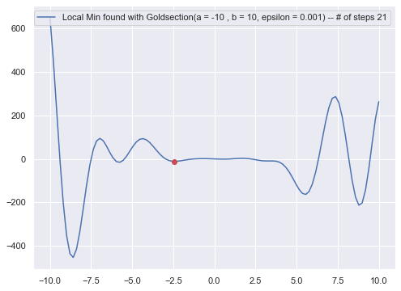

```python
a = -10
b = 10
eps = 0.001
goldsec2,gold_2_x,iteration = goldsection(a,b,eps,f)

plt.plot(X,f(X), label = f"Local Min found with Goldsection(a = -10 , b = 10, epsilon = 0.001) -- # of steps {iteration}" )
plt.plot(gold_2_x, f(gold_2_x), 'ro')
plt.legend()
plt.plot();
```

```python
goldsec2
```

| Iteration | a | b | x | y | f(x) | f(y) | \|x^(k+1)−x^k\| / \|x^k−x^(k-1)\| | -log\|x^(k+1)−x^k\| + log \|x^k−x^(k-1)\| |
| --- | --- | --- | --- | --- | --- | --- | --- | --- |
| 0 | -10.000000 | 2.360000 | -5.278480 | -2.360000 | 19.808600 | -11.261796 | 0.618000 | 0.481267 |
| 1 | -5.278480 | 2.360000 | -2.360000 | -0.557899 | -11.261796 | 1.257354 | 0.618000 | 0.481267 |
| 2 | -5.278480 | -0.557899 | -3.475218 | -2.360000 | 35.276732 | -11.261796 | 0.618000 | 0.481267 |
| 3 | -3.475218 | -0.557899 | -2.360000 | -1.672315 | -11.261796 | -3.801306 | 0.618000 | 0.481267 |
| 4 | -3.475218 | -1.672315 | -2.786509 | -2.360000 | -6.792009 | -11.261796 | 0.618000 | 0.481267 |
| 5 | -2.786509 | -1.672315 | -2.360000 | -2.097937 | -11.261796 | -9.132329 | 0.618000 | 0.481267 |
| 6 | -2.786509 | -2.097937 | -2.523475 | -2.360000 | -11.089423 | -11.261796 | 0.618000 | 0.481267 |
| 7 | -2.523475 | -2.097937 | -2.360000 | -2.260493 | -11.261796 | -10.714180 | 0.618000 | 0.481267 |
| 8 | -2.523475 | -2.260493 | -2.423016 | -2.360000 | -11.375195 | -11.261796 | 0.618000 | 0.481267 |
| 9 | -2.523475 | -2.360000 | -2.461027 | -2.423016 | -11.339637 | -11.375195 | 0.621619 | 0.475428 |
| 10 | -2.461027 | -2.360000 | -2.423016 | -2.398592 | -11.375195 | -11.355497 | 0.618000 | 0.481267 |
| 11 | -2.461027 | -2.398592 | -2.437177 | -2.423016 | -11.371651 | -11.375195 | 0.618000 | 0.481267 |
| 12 | -2.437177 | -2.398592 | -2.423016 | -2.413332 | -11.375195 | -11.371221 | 0.618000 | 0.481267 |
| 13 | -2.437177 | -2.413332 | -2.428068 | -2.423016 | -11.375221 | -11.375195 | 0.618000 | 0.481267 |
| 14 | -2.437177 | -2.423016 | -2.431767 | -2.428068 | -11.374336 | -11.375221 | 0.593896 | 0.521051 |
| 15 | -2.431767 | -2.423016 | -2.428068 | -2.426359 | -11.375221 | -11.375371 | 0.618000 | 0.481267 |
| 16 | -2.428068 | -2.423016 | -2.426359 | -2.424946 | -11.375371 | -11.375372 | 0.577329 | 0.549342 |
| 17 | -2.426359 | -2.423016 | -2.424946 | -2.424293 | -11.375372 | -11.375335 | 0.661667 | 0.412992 |
| 18 | -2.426359 | -2.424293 | -2.425570 | -2.424946 | -11.375385 | -11.375372 | 0.618000 | 0.481267 |
| 19 | -2.426359 | -2.424946 | -2.425819 | -2.425570 | -11.375384 | -11.375385 | 0.683933 | 0.379895 |
| 20 | -2.425819 | -2.424946 | -2.425570 | -2.425279 | -11.375385 | -11.375382 | 0.618000 | 0.481267 |